# HW 03

Author

Seldon David Kyle

## 1 - Du Bois [^1]

```r
income <- read_csv("data/income.csv")
```

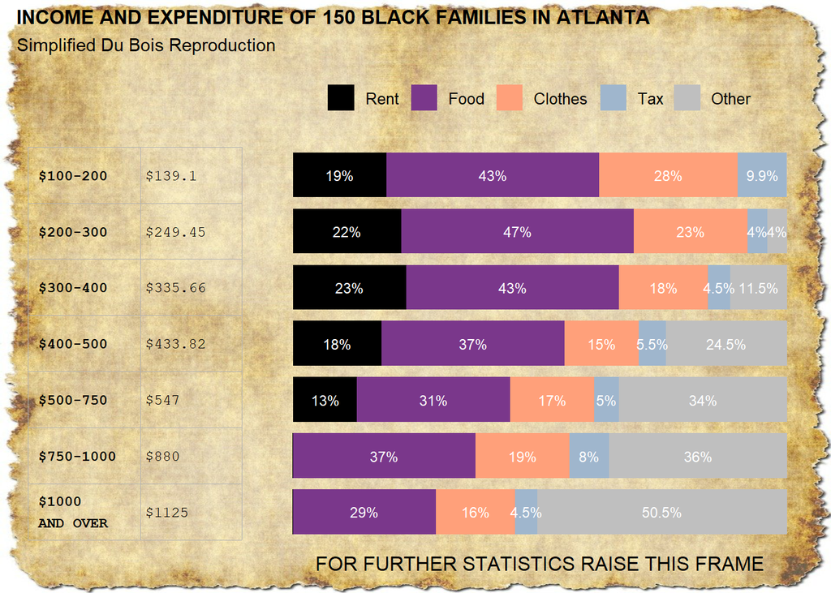

```r
# recode label for line break
income <- income |>
  mutate(Class = recode(Class, "$1000 AND OVER" = "$1000\nAND OVER"))

# create factor levels
class_levels <- rev(c(
  "$100-200", "$200-300", "$300-400", "$400-500",
  "$500-750", "$750-1000", "$1000\nAND OVER"
))

# left table
label_table <- income |>
  mutate(Class = factor(Class, levels = class_levels)) |>
  ggplot(aes(y = Class)) +
  # grid lines
  geom_segment(data = tibble(y = seq(0.5, 7.5, 1)),
               aes(x = 0.9, xend = 2.9, y = y, yend = y),
               inherit.aes = FALSE, color = "gray70", linewidth = 0.2) +
  geom_segment(data = tibble(x = c(0.9, 1.95, 2.9)),
               aes(x = x, xend = x, y = 0.5, yend = 7.5),
               inherit.aes = FALSE, color = "gray70", linewidth = 0.2) +
  # class and income text
  geom_text(aes(x = 1, label = Class),
            hjust = 0, size = 3.2, fontface = "bold", family = "mono") +
  geom_text(aes(x = 2, label = paste0("$", Average_Income)),
            hjust = 0, size = 3.2, family = "mono") +
  scale_y_discrete(limits = class_levels) +
  xlim(0.9, 2.9) +
  theme_void() +
  theme(
    plot.margin = margin(5, 0, 5, 5),
    axis.text.y = element_blank(),
    plot.background = element_rect(fill = NA, color = NA)
  )

# data prep chart data
data_long <- income |>
  pivot_longer(cols = Rent:Other, names_to = "type", values_to = "measurement") |>
  mutate(
    type = factor(type, levels = c("Rent", "Food", "Clothes", "Tax", "Other")),
    Class = factor(Class, levels = class_levels)
  )

# get rid of noise
data_long$measurement[data_long$measurement == 0] <- 0.1

# our colors
category_colors <- c(
  Rent = "black",
  Food = "mediumorchid4",
  Clothes = "lightsalmon1",
  Tax = "slategray3",
  Other = "gray75"
)

# our plot
bar_plot <- ggplot(data_long, aes(x = Class, y = measurement, fill = type)) +
  geom_bar(stat = "identity", width = 0.8) +
  geom_text(
    aes(label = ifelse(measurement >= 1, paste0(measurement, "%"), "")),
    position = position_stack(vjust = 0.5),
    size = 3, color = "white"
  ) +
  scale_y_reverse() +
  scale_fill_manual(values = category_colors) +
  coord_flip() +
  labs(x = NULL, y = "FOR FURTHER STATISTICS RAISE THIS FRAME") +
  theme_minimal(base_size = 12) +
  theme(
    axis.text = element_blank(),
    axis.ticks = element_blank(),
    panel.grid = element_blank(),
    legend.title = element_blank(),
    legend.position = "top",
    legend.direction = "horizontal",
    legend.justification = "center",
    plot.background = element_rect(fill = NA, color = NA)
  )

bg_img <- readJPEG("images/parchment.jpg")
parchment_grob <- rasterGrob(bg_img, width = unit(1, "npc"), height = unit(1, "npc"))

# stitch
final_plot <- (label_table + bar_plot + plot_layout(widths = c(1.3, 3))) +
  plot_annotation(
    title = "INCOME AND EXPENDITURE OF 150 BLACK FAMILIES IN ATLANTA",
    subtitle = "Simplified Du Bois Reproduction",
    theme = theme(
      plot.title = element_text(face = "bold", hjust = 0, size = 12),
      plot.subtitle = element_text(hjust = 0),
      plot.background = element_rect(fill = "transparent", color = NA)
    )
  )

# draw plot on parchment image
ggdraw() +
  draw_grob(parchment_grob) +
  draw_plot(final_plot)
```

## 2 - COVID survey - interpret

This plot compares medical and nursing students’ responses to a series of statements about the COVID-19 vaccine. Responses are broken down by demographic and professional groups and displayed as a faceted Likert mean plot. Each point represents the mean Likert score for a subgroup, with error bars spanning the 10th to 90th percentile to show response variability.

#### Directionality of Agreement by Statement

Out of the six statements students responded to, five are positively framed. “I believe the vaccine is safe,” strong agreement–score lower–means pro-belief in the vaccine. However, “I am concerned about the safety and side effects of the vaccine” is negatively framed–score lower means high concern.

With the exception of side effects, these questions are *almost* the same so you would think they have the same, but flipped, scores. The error bars appear to be the same, but the mean of the positive statement is agreed upon much more than the negative sentiment is disagreed with.

There are a few reasons this may be occurring; I’ll mention two. First, agreeing with safety may be easier than disagreeing with concern, especially for people training in healthcare, where some level of risk is more accepted. Second, it’s just a survey, and disagreeing with a negatively worded statement requires more cognitive effort than simply agreeing with a positively framed one. Understanding that you’re rejecting a negative takes more mental processing than offering straightforward agreement.

#### Vaccinated vs. Unvaccinated Respondents

Across all response statements, students who reported being vaccinated for COVID-19 show markedly more favorable attitudes toward the COVID-19 vaccine than those who were unvaccinated. With the exception of statements one and three, vaccinated students not only had more favorable mean scores, but also considerably less variance, as shown by the shorter error bars.

Whether students got vaccinated because they held favorable views, or developed those views after getting vaccinated, is not entirely clear. Likely, it’s a bit of both. What does seem clear is that vaccination experience reinforces advocacy: among vaccinated students, the mean response is nearly perfectly favorable—with very little variation across individuals.

#### Flu Vaccination as a Marker of Vaccine Trust

Students who received the flu vaccine gave more favorable responses to the survey’s trust-related statements. Excluding statements one and three, they also showed noticeably less variance in their responses. This supports the idea that individuals who receive vaccines tend to have a general trust in vaccines and the approval process—whether or not they fully understand the details of that process.

As with previous examples, the causal relationship is unclear: do students trust vaccines and therefore choose to get vaccinated, or does the act of vaccination reinforce their trust? Further statistical testing would be needed to determine whether the same individuals make up both the flu and COVID vaccination cohorts.

## 3 - COVID survey - reconstruct

```r
survey <- read_csv("data/covid-survey.csv", skip = 1)
```

```r
dim(survey)
```

```
[1] 1121   14
```

```r
survey_clean <- survey |>
  filter(!if_all(-response_id, is.na))

dim(survey_clean)
```

```
[1] 1111   14
```

```r
survey_labeled <- survey_clean |>
  mutate(
    exp_already_vax = recode(exp_already_vax,
      `0` = "No", `1` = "Yes"
    ),
    exp_flu_vax = recode(exp_flu_vax,
      `0` = "No", `1` = "Yes"
    ),
    exp_profession = recode(exp_profession,
      `0` = "Medical", `1` = "Nursing"
    ),
    exp_gender = recode(exp_gender,
      `0` = "Male",
      `1` = "Female",
      `3` = "Non-binary / Third gender",
      `4` = "Prefer not to say"
    ),
    exp_race = recode(exp_race,
      `1` = "American Indian / Alaskan Native",
      `2` = "Asian",
      `3` = "Black / African American",
      `4` = "Native Hawaiian / Other Pacific Islander",
      `5` = "White"
    ),
    exp_ethnicity = recode(exp_ethnicity,
      `1` = "Hispanic / Latino",
      `2` = "Non-Hispanic / Non-Latino"
    ),
    exp_age_bin = recode(exp_age_bin,
      `0` = "<20",
      `20` = "21–25",
      `25` = "26–30",
      `30` = ">30"
    )
  )
```

```r
dim(survey_labeled)
```

```
[1] 1111   14
```

```r
covid_survey_longer <- survey_labeled |>
  pivot_longer(
    cols = starts_with("exp_"),
    names_to = "explanatory",
    values_to = "explanatory_value"
  ) |>
  filter(!is.na(explanatory_value)) |>
  pivot_longer(
    cols = starts_with("resp_"),
    names_to = "response",
    values_to = "response_value"
  )
```

The first pivot_longer reshapes the data from wide to long. All columns that begin with “exp_” are turned into two columns, “explanatory” that holds the name of the variable and “explanatory_value” holds the actual value for that column.

The second is also reshaping from wide to long. This time all columns that begin with “resp_” are turned into two columns, “response” which is the name of the response question and “response_value” with the corresponding score.

```r
covid_survey_longer
```

```
# A tibble: 43,428 × 5
   response_id explanatory    explanatory_value response          response_value
         <dbl> <chr>          <chr>             <chr>                      <dbl>
 1           1 exp_profession Nursing           resp_safety                    5
 2           1 exp_profession Nursing           resp_confidence_…              2
 3           1 exp_profession Nursing           resp_concern_saf…              2
 4           1 exp_profession Nursing           resp_feel_safe_a…              1
 5           1 exp_profession Nursing           resp_will_recomm…              1
 6           1 exp_profession Nursing           resp_trust_info                1
 7           1 exp_flu_vax    Yes               resp_safety                    5
 8           1 exp_flu_vax    Yes               resp_confidence_…              2
 9           1 exp_flu_vax    Yes               resp_concern_saf…              2
10           1 exp_flu_vax    Yes               resp_feel_safe_a…              1
# ℹ 43,418 more rows
```

```r
covid_survey_summary_stats_by_group <- covid_survey_longer |>
  group_by(explanatory, explanatory_value, response) |>
  summarize(
    mean = mean(response_value, na.rm = TRUE),
    low  = quantile(response_value, 0.10, na.rm = TRUE),
    high = quantile(response_value, 0.90, na.rm = TRUE),
    .groups = "drop"
  )

covid_survey_summary_stats_by_group
```

```
# A tibble: 126 × 6
   explanatory explanatory_value response                 mean   low  high
   <chr>       <chr>             <chr>                   <dbl> <dbl> <dbl>
 1 exp_age_bin 21–25             resp_concern_safety      3.32     2     5
 2 exp_age_bin 21–25             resp_confidence_science  1.31     1     2
 3 exp_age_bin 21–25             resp_feel_safe_at_work   1.20     1     2
 4 exp_age_bin 21–25             resp_safety              1.95     1     5
 5 exp_age_bin 21–25             resp_trust_info          1.29     1     2
 6 exp_age_bin 21–25             resp_will_recommend      1.09     1     1
 7 exp_age_bin 26–30             resp_concern_safety      3.35     1     5
 8 exp_age_bin 26–30             resp_confidence_science  1.40     1     2
 9 exp_age_bin 26–30             resp_feel_safe_at_work   1.29     1     2
10 exp_age_bin 26–30             resp_safety              2.16     1     5
# ℹ 116 more rows
```

```r
covid_survey_summary_stats_all <- covid_survey_longer |>
  group_by(response) |>
  summarize(
    mean = mean(response_value, na.rm = TRUE),
    low  = quantile(response_value, 0.10, na.rm = TRUE),
    high = quantile(response_value, 0.90, na.rm = TRUE),
    explanatory = "All",
    explanatory_value = factor(""),
    .groups = "drop"
  )


covid_survey_summary_stats_all
```

```
# A tibble: 6 × 6
  response                 mean   low  high explanatory explanatory_value
  <chr>                   <dbl> <dbl> <dbl> <chr>       <fct>
1 resp_concern_safety      3.28     1     5 All         ""
2 resp_confidence_science  1.43     1     2 All         ""
3 resp_feel_safe_at_work   1.36     1     2 All         ""
4 resp_safety              2.03     1     5 All         ""
5 resp_trust_info          1.40     1     2 All         ""
6 resp_will_recommend      1.21     1     2 All         ""
```

```r
covid_survey_summary_stats <- bind_rows(
  covid_survey_summary_stats_all,
  covid_survey_summary_stats_by_group
)
```

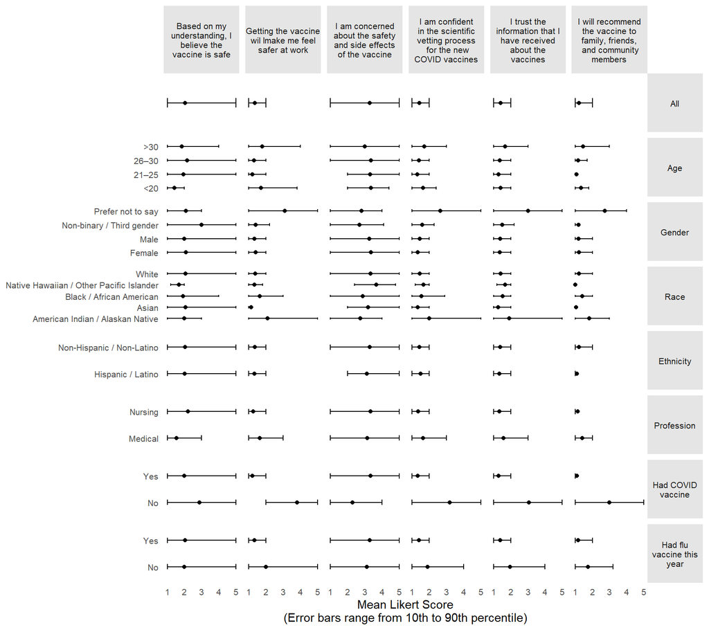

```r
# labels for responses--facets
response_labels <- c(
  resp_safety = "Based on my\nunderstanding, I\nbelieve the\nvaccine is safe",
  resp_confidence_science = "I am confident\nin the scientific\nvetting process\n for the new\nCOVID vaccines",
  resp_feel_safe_at_work = "Getting the vaccine\nwil lmake me feel\nsafer at work",
  resp_will_recommend = "I will recommend\nthe vaccine to\nfamily, friends,\n and community\nmembers",
  resp_trust_info = "I trust the\ninformation that I\nhave received\nabout the\nvaccines",
  resp_concern_safety = "I am concerned\nabout the safety\nand side effects\nof the vaccine"
)

# factor level order for response variable
covid_survey_summary_stats <- covid_survey_summary_stats |>
  mutate(response = factor(response, levels = c(
    "resp_safety",
    "resp_feel_safe_at_work",
    "resp_concern_safety",
    "resp_confidence_science",
    "resp_trust_info",
    "resp_will_recommend"
  )))

# labels for explanatory variables
explanatory_labels <- c(
  exp_age_bin       = "Age",
  exp_gender        = "Gender",
  exp_race          = "Race",
  exp_ethnicity     = "Ethnicity",
  exp_profession    = "Profession",
  exp_already_vax   = "Had COVID\nvaccine",
  exp_flu_vax       = "Had flu\nvaccine this\nyear",
  All               = "All"
)

# row facet order
covid_survey_summary_stats <- covid_survey_summary_stats |>
  mutate(
    explanatory = fct_relevel(
      explanatory,
      "All",
      "exp_age_bin",
      "exp_gender",
      "exp_race",
      "exp_ethnicity",
      "exp_profession",
      "exp_already_vax",
      "exp_flu_vax"

    )
  )

# filter dataset for levels
covid_survey_summary_stats <- covid_survey_summary_stats |>
  filter(
    explanatory == "All" |
    (explanatory == "exp_age_bin" &
       explanatory_value %in% c("<20", "21–25", "26–30", ">30")) |
    (explanatory == "exp_gender" &
       explanatory_value %in% c("Male",
                                "Female",
                                "Non-binary / Third gender",
                                "Prefer not to say")) |
    (explanatory == "exp_race" &
       explanatory_value %in% c("American Indian / Alaskan Native",
                                "Asian",
                                "Black / African American",
                                "Native Hawaiian / Other Pacific Islander",
                                "White")) |
    (explanatory == "exp_ethnicity"   &
       explanatory_value %in% c("Hispanic / Latino",
                                "Non-Hispanic / Non-Latino")) |
    (explanatory == "exp_profession"  &
       explanatory_value %in% c("Medical",
                                "Nursing")) |
    (explanatory == "exp_already_vax" & explanatory_value %in% c("Yes", "No")) |
    (explanatory == "exp_flu_vax"     & explanatory_value %in% c("Yes", "No"))
  )

# reorder explanatory_value within the group
covid_survey_summary_stats <- covid_survey_summary_stats |>
  group_by(explanatory) |>
  mutate(
    explanatory_value = case_when(
      explanatory == "exp_age_bin" ~ factor(explanatory_value, levels = c(
        ">30",
        "26–30",
        "21–25",
        "<20")),
      explanatory == "exp_gender" ~ factor(explanatory_value, levels = c(
        "Prefer not to say",
        "Non-binary / Third gender",
        "Male",
        "Female" )),
      explanatory == "exp_race" ~ factor(explanatory_value, levels = c(
        "White",
        "Native Hawaiian / Other Pacific Islander",
        "Black / African American",
        "Asian",
        "American Indian / Alaskan Native")),
      explanatory == "exp_ethnicity" ~ factor(explanatory_value, levels = c(
        "Non-Hispanic / Non-Latino",
        "Hispanic / Latino")),
      explanatory == "exp_profession" ~ factor(explanatory_value, levels = c(
        "Nursing",
        "Medical")),
      explanatory == "exp_already_vax" ~ factor(explanatory_value, levels = c(
        "Yes",
        "No")),
      explanatory == "exp_flu_vax" ~ factor(explanatory_value, levels = c(
        "Yes",
        "No")),
      TRUE ~ factor(explanatory_value)
    )
  ) |>
  ungroup()

# and we plot
ggplot(covid_survey_summary_stats, aes(y = fct_rev(explanatory_value), x = mean)) +
  geom_point() +
  geom_errorbarh(aes(xmin = low, xmax = high), height = 0.2) +
  facet_grid(
    rows = vars(explanatory),
    cols = vars(response),
    scales = "free_y",
    labeller = labeller(
      response = response_labels,
      explanatory = explanatory_labels
    ),
    drop = TRUE
  ) +
  scale_x_continuous(breaks = 1:5, limits = c(1, 5)) +
  theme_minimal() +
  theme(
    strip.background = element_rect(fill = "gray90", color = NA),
    strip.text.y = element_text(size = 8, angle = 0),
    strip.text.x = element_text(size = 8, margin = margin(t = 10, b = 10)),
    axis.text.y = element_text(size = 8),
    axis.text.x = element_text(size = 8),
    panel.grid.major.y = element_blank(),
    panel.grid.minor.y = element_blank(),
    panel.grid.major.x = element_blank(),
    panel.grid.minor.x = element_blank()
  ) +
  labs(
    x = "Mean Likert Score\n(Error bars range from 10th to 90th percentile)",
    y = NULL,
    title =NULL
  )
```

## 4 - COVID survey - re-reconstruct

```r
# change the range to 0.25-0.75
covid_survey_summary_stats_by_group_quar <- covid_survey_longer |>
  group_by(explanatory, explanatory_value, response) |>
  summarize(
    mean = mean(response_value, na.rm = TRUE),
    low  = quantile(response_value, 0.25, na.rm = TRUE),
    high = quantile(response_value, 0.75, na.rm = TRUE),
    .groups = "drop"
  )

covid_survey_summary_stats_by_group_quar
```

```
# A tibble: 126 × 6
   explanatory explanatory_value response                 mean   low  high
   <chr>       <chr>             <chr>                   <dbl> <dbl> <dbl>
 1 exp_age_bin 21–25             resp_concern_safety      3.32     2   4
 2 exp_age_bin 21–25             resp_confidence_science  1.31     1   2
 3 exp_age_bin 21–25             resp_feel_safe_at_work   1.20     1   1
 4 exp_age_bin 21–25             resp_safety              1.95     1   2
 5 exp_age_bin 21–25             resp_trust_info          1.29     1   1
 6 exp_age_bin 21–25             resp_will_recommend      1.09     1   1
 7 exp_age_bin 26–30             resp_concern_safety      3.35     2   4.5
 8 exp_age_bin 26–30             resp_confidence_science  1.40     1   2
 9 exp_age_bin 26–30             resp_feel_safe_at_work   1.29     1   1
10 exp_age_bin 26–30             resp_safety              2.16     1   4
# ℹ 116 more rows
```

```r
# change the range to 0.25-0.75
covid_survey_summary_stats_all_quar <- covid_survey_longer |>
  group_by(response) |>
  summarize(
    mean = mean(response_value, na.rm = TRUE),
    low  = quantile(response_value, 0.25, na.rm = TRUE),
    high = quantile(response_value, 0.75, na.rm = TRUE),
    explanatory = "All",
    explanatory_value = factor(""),
    .groups = "drop"
  )


covid_survey_summary_stats_all_quar
```

```
# A tibble: 6 × 6
  response                 mean   low  high explanatory explanatory_value
  <chr>                   <dbl> <dbl> <dbl> <chr>       <fct>
1 resp_concern_safety      3.28     2     4 All         ""
2 resp_confidence_science  1.43     1     2 All         ""
3 resp_feel_safe_at_work   1.36     1     1 All         ""
4 resp_safety              2.03     1     3 All         ""
5 resp_trust_info          1.40     1     2 All         ""
6 resp_will_recommend      1.21     1     1 All         ""
```

```r
# combine the dataframes
covid_survey_summary_stats_quar <- bind_rows(
  covid_survey_summary_stats_all_quar,
  covid_survey_summary_stats_by_group_quar
)
```

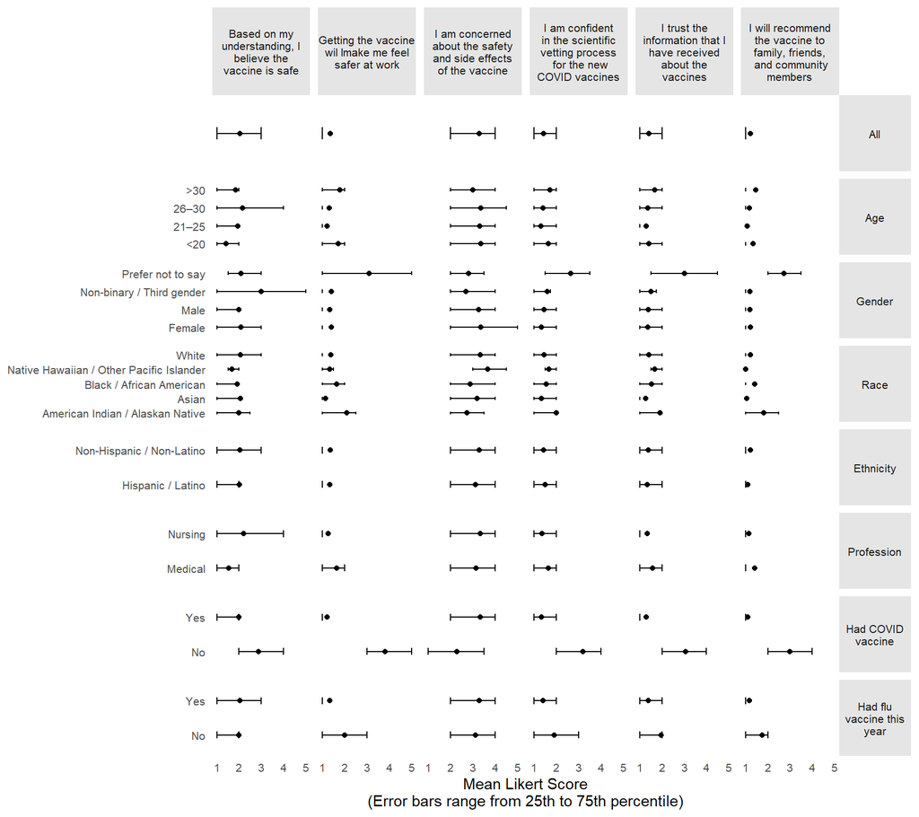

```r
# labels for responses--facets
response_labels <- c(
  resp_safety = "Based on my\nunderstanding, I\nbelieve the\nvaccine is safe",
  resp_confidence_science = "I am confident\nin the scientific\nvetting process\n for the new\nCOVID vaccines",
  resp_feel_safe_at_work = "Getting the vaccine\nwil lmake me feel\nsafer at work",
  resp_will_recommend = "I will recommend\nthe vaccine to\nfamily, friends,\n and community\nmembers",
  resp_trust_info = "I trust the\ninformation that I\nhave received\nabout the\nvaccines",
  resp_concern_safety = "I am concerned\nabout the safety\nand side effects\nof the vaccine"
)

# factor level order for response variable
covid_survey_summary_stats_quar <- covid_survey_summary_stats_quar |>
  mutate(response = factor(response, levels = c(
    "resp_safety",
    "resp_feel_safe_at_work",
    "resp_concern_safety",
    "resp_confidence_science",
    "resp_trust_info",
    "resp_will_recommend"
  )))

# labels for explanatory variables
explanatory_labels <- c(
  exp_age_bin       = "Age",
  exp_gender        = "Gender",
  exp_race          = "Race",
  exp_ethnicity     = "Ethnicity",
  exp_profession    = "Profession",
  exp_already_vax   = "Had COVID\nvaccine",
  exp_flu_vax       = "Had flu\nvaccine this\nyear",
  All               = "All"
)

# row facet order
covid_survey_summary_stats_quar <- covid_survey_summary_stats_quar |>
  mutate(
    explanatory = fct_relevel(
      explanatory,
      "All",
      "exp_age_bin",
      "exp_gender",
      "exp_race",
      "exp_ethnicity",
      "exp_profession",
      "exp_already_vax",
      "exp_flu_vax"

    )
  )

# filter dataset for levels
covid_survey_summary_stats_quar <- covid_survey_summary_stats_quar |>
  filter(
    explanatory == "All" |
    (explanatory == "exp_age_bin" &
       explanatory_value %in% c("<20", "21–25", "26–30", ">30")) |
    (explanatory == "exp_gender" &
       explanatory_value %in% c("Male",
                                "Female",
                                "Non-binary / Third gender",
                                "Prefer not to say")) |
    (explanatory == "exp_race" &
       explanatory_value %in% c("American Indian / Alaskan Native",
                                "Asian",
                                "Black / African American",
                                "Native Hawaiian / Other Pacific Islander",
                                "White")) |
    (explanatory == "exp_ethnicity"   &
       explanatory_value %in% c("Hispanic / Latino",
                                "Non-Hispanic / Non-Latino")) |
    (explanatory == "exp_profession"  &
       explanatory_value %in% c("Medical",
                                "Nursing")) |
    (explanatory == "exp_already_vax" & explanatory_value %in% c("Yes", "No")) |
    (explanatory == "exp_flu_vax"     & explanatory_value %in% c("Yes", "No"))
  )

# reorder explanatory_value within the group
covid_survey_summary_stats_quar <- covid_survey_summary_stats_quar |>
  group_by(explanatory) |>
  mutate(
    explanatory_value = case_when(
      explanatory == "exp_age_bin" ~ factor(explanatory_value, levels = c(
        ">30",
        "26–30",
        "21–25",
        "<20")),
      explanatory == "exp_gender" ~ factor(explanatory_value, levels = c(
        "Prefer not to say",
        "Non-binary / Third gender",
        "Male",
        "Female" )),
      explanatory == "exp_race" ~ factor(explanatory_value, levels = c(
        "White",
        "Native Hawaiian / Other Pacific Islander",
        "Black / African American",
        "Asian",
        "American Indian / Alaskan Native")),
      explanatory == "exp_ethnicity" ~ factor(explanatory_value, levels = c(
        "Non-Hispanic / Non-Latino",
        "Hispanic / Latino")),
      explanatory == "exp_profession" ~ factor(explanatory_value, levels = c(
        "Nursing",
        "Medical")),
      explanatory == "exp_already_vax" ~ factor(explanatory_value, levels = c(
        "Yes",
        "No")),
      explanatory == "exp_flu_vax" ~ factor(explanatory_value, levels = c(
        "Yes",
        "No")),
      TRUE ~ factor(explanatory_value)
    )
  ) |>
  ungroup()

# and we plot
ggplot(covid_survey_summary_stats_quar, aes(y = fct_rev(explanatory_value), x = mean)) +
  geom_point() +
  geom_errorbarh(aes(xmin = low, xmax = high), height = 0.2) +
  facet_grid(
    rows = vars(explanatory),
    cols = vars(response),
    scales = "free_y",
    labeller = labeller(
      response = response_labels,
      explanatory = explanatory_labels
    ),
    drop = TRUE
  ) +
  scale_x_continuous(breaks = 1:5, limits = c(1, 5)) +
  theme_minimal() +
  theme(
    strip.background = element_rect(fill = "gray90", color = NA),
    strip.text.y = element_text(size = 8, angle = 0),
    strip.text.x = element_text(size = 8, margin = margin(t = 10, b = 10)),
    axis.text.y = element_text(size = 8),
    axis.text.x = element_text(size = 8),
    panel.grid.major.y = element_blank(),
    panel.grid.minor.y = element_blank(),
    panel.grid.major.x = element_blank(),
    panel.grid.minor.x = element_blank()
  ) +
  labs(
    x = "Mean Likert Score\n(Error bars range from 25th to 75th percentile)",
    y = NULL,
    title =NULL
  )
```

#### Comparison to 10th-90th Plot

The interquartile range excludes more extreme responses, which results in narrower error bars. This makes the overall plot look tighter, making comparisons easier.

The main conclusion that changed is that some answers which previously appeared to show moderate variance now show almost none when using the new plot. Responses to the question “*I will recommend the vaccine…*” are a good example. In the first plot, almost every group demonstrated a moderate amount of variance, while in the second plot, a majority show almost no variance at all.

## 5 - COVID survey - another view

```r
# pivot longer to get all responses in one column
likert_long <- survey_labeled |>
  select(starts_with("resp_")) |>
  pivot_longer(
    everything(),
    names_to = "question",
    values_to = "score"
  ) |>
  filter(!is.na(score))  # Remove any missing responses

# count responses per question and score
likert_summary <- likert_long |>
  group_by(question, score) |>
  summarise(n = n(), .groups = "drop") |>
  group_by(question) |>
  mutate(
    percent = n / sum(n) * 100,
    score = factor(score, levels = 1:5)  # ensure correct order
  )
```

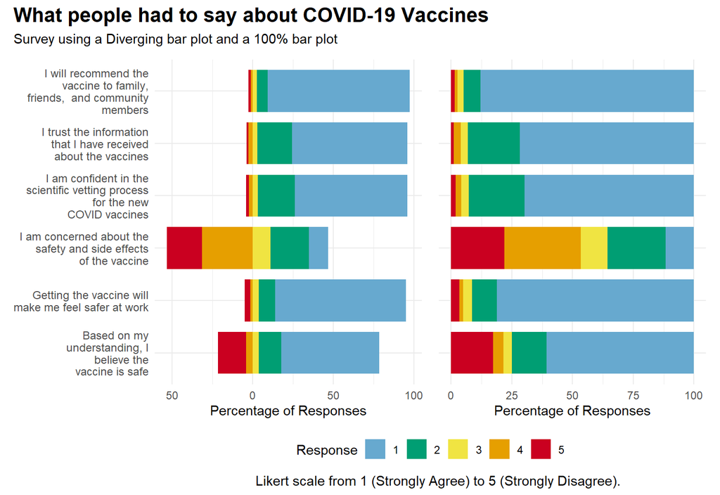

```r
question_order <- c(
  "Based on my\nunderstanding, I\nbelieve the\nvaccine is safe",
  "Getting the vaccine will\nmake me feel safer at work",
  "I am concerned about the\nsafety and side effects\nof the vaccine",
  "I am confident in the\nscientific vetting process\n for the new\nCOVID vaccines",
  "I trust the information\nthat I have received\nabout the vaccines",
  "I will recommend the\nvaccine to family,\nfriends,  and community\nmembers"
)

# define score levels
score_levels <- c("1", "2", "3", "5", "4")

# apply label mapping, factor order for the diverging chart
likert_summary_div <- likert_summary |>
  mutate(
    question = recode(question,
  resp_safety = "Based on my\nunderstanding, I\nbelieve the\nvaccine is safe",
  resp_feel_safe_at_work = "Getting the vaccine will\nmake me feel safer at work",
  resp_concern_safety = "I am concerned about the\nsafety and side effects\nof the vaccine",
  resp_confidence_science = "I am confident in the\nscientific vetting process\n for the new\nCOVID vaccines",
  resp_trust_info = "I trust the information\nthat I have received\nabout the vaccines",
  resp_will_recommend = "I will recommend the\nvaccine to family,\nfriends,  and community\nmembers"
),
    question = factor(question, levels = question_order),
    score = factor(score, levels = score_levels), # score factor levels updated here for plotting order
    percent_signed = ifelse(as.numeric(score) <= 3, percent, -percent)
  )

# need to set the levels back
score_levels_hundo <- c("1", "2", "3", "4", "5")

# this chart is basically the same, so we just overwrite the mutation elements
likert_summary_hundo <- likert_summary_div |>
  mutate(
    score = factor(score, levels = score_levels_hundo),
    percent_signed = ifelse(as.numeric(score) <= 5, percent, -percent)
  )

# color palette
likert_colors <- c(
  "1" = "#67a9cf",
  "2" = "#009E73",
  "3" = "#F0E442",
  "4" = "#E69F00",
  "5" = "#ca0020"
)

# the plots are basically the same so make a function
make_likert_plot <- function(data, show_y_axis = TRUE) {
  ggplot(data, aes(x = percent_signed, y = question, fill = score)) +
    geom_col(width = 0.8) +
    scale_fill_manual(
      values = likert_colors,
      name = "Response",
      breaks = c("1", "2", "3", "4", "5")
    ) +
    scale_x_continuous(labels = abs, name = "Percentage of Responses") +
    labs(title = NULL, y = NULL) +
    theme_minimal() +
    theme(
      plot.title = element_text(face = "bold", size = 14, hjust = 0.5),
      axis.text.y = if (show_y_axis) element_text(size = 9) else element_blank(),
      legend.position = "none"
    )
}


#| label: fig-diverging
#| fig-alt: "Diverging bar chart showing COVID-19 vaccine attitudes. Each question is split by response category, with stronger agreement to the right and stronger disagreement to the left."
div_plot   <- make_likert_plot(likert_summary_div,  show_y_axis = TRUE)

#| label: fig-stacked
#| fig-alt: "100% stacked bar chart showing full distribution of responses for each COVID-19 vaccine question."
hundo_plot <- make_likert_plot(likert_summary_hundo, show_y_axis = FALSE)

# stitch

#| label: fig-combined
#| fig-alt: "Side-by-side bar charts comparing COVID-19 vaccine attitudes: diverging layout on the left and 100% stacked layout on the right. Each bar represents the percent of responses to different questions."
(div_plot +
   hundo_plot +
   plot_layout(widths = c(1, 1), guides = "collect") &
   theme(legend.position = "bottom")
) +
  plot_annotation(
    title = "What people had to say about COVID-19 Vaccines",
    subtitle = "Survey using a Diverging bar plot and a 100% bar plot",
    caption = "Likert scale from 1 (Strongly Agree) to 5 (Strongly Disagree).",
    theme = theme(
      plot.title = element_text(face = "bold", size = 16, hjust = 0),
      plot.caption = element_text(size = 11, hjust = 0.74, margin = margin(t = 1)),
    )
  )
```

Inspiration for formatting, labeling, and titling taken from Dr. Greg Chism INFO-526-su25

#### Comparing the charts

The diverging bar chart communicates sentiment across question and whether opinions are positive or negative. The 100% bar chart communicates how diverse opinions are. One shows direction and the other shows distribution.

## Footnotes

[^1]: AI was used for assistance in this project. It was used for code clarification, exception explanations, and discussions on how grid, cowplot, and other packages operate. I used code snippets only when I was unable to resolve an issue independently. All text is authored exclusively by me.